# R Notebook

```r
setwd('D:/iCloud/iCloudDrive/Master Big Data/Data Analytics - Teoria_Practica/_r_exercises/5-Linear Regression')

BcnPisos = read.delim("bcn_pisos.txt")

library(ggplot2)
library(dplyr)
library(magrittr)
library(sampling)
```

### *1. Enumere cuales son las hipótesis que asumimos al hacer una regresión múltiple entre una variable de respuesta y y unas variables predictoras, x1, …, xp.*

### *2. En un modelo de regresión, como se calcula y como se interpreta el coeficiente de determinación R2.*

R2 se interpreta como un coeficiente o proporcion de la variabilidad de la variable de respuesta explicada por el modelo (en otras palabras, que tanto explica el vector de ajuste al vector respuesta).

Valores de R que se aproximen a:

- 1 son buenos,
- entre 0.4 y 0.7 son medianos
- menores a 0.4 son bajos
- cercanos a 0 son inservibles.

Se calcula a través del coseno cuadrado entre la variable respuesta y la variable predictora, o lo que es lo mismo:

*Sum Sq (vector ajuste) / Sum Sq (Vector Respuesta)*

### *3. Lea el fichero “BCN_pisos.txt”. Del fichero resultante seleccione 2/3 partes como muestra de training y la tercera parte restante como muestra test.*

```r
length = nrow(BcnPisos)
index = sample(1:length, length * 0.66)

setTraining = BcnPisos[index,]
setTest = BcnPisos[-index,]
```

### *4. Con la muestra de training, efectúe la representación gráfica de la variable “Valor” respecto del resto de variables del fichero. Calcule la correlación entre la variable “Valor” y el resto de variables numéricas.*

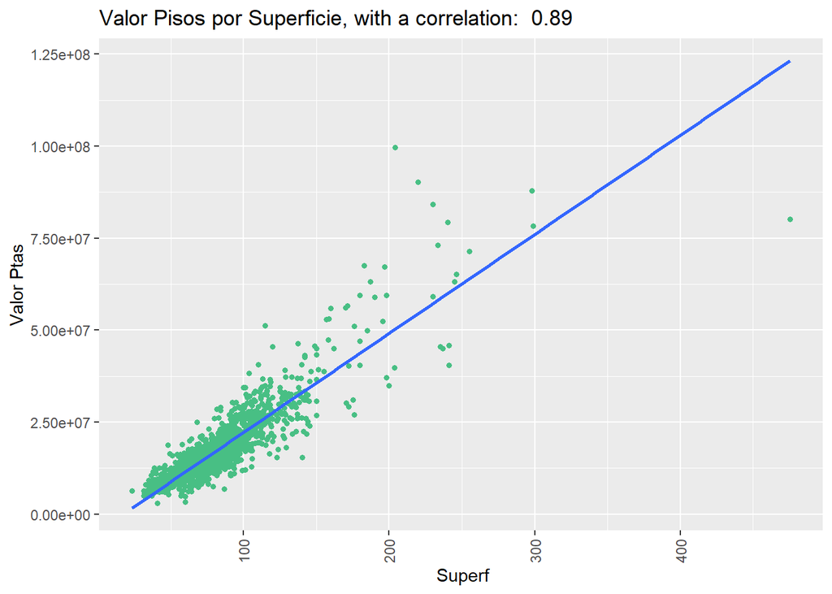

```r
colorPalett = c("#99E47E", "#48BF84", "#439775", "#3C7A80", "#D65F65")

correlation = round(cor(setTraining$Valor, setTraining$Superf),3)

# Line Chart: Valor Medio Pisos

ValorChart = ggplot(setTraining, aes(y = Valor, x = Superf, group = 1)) + geom_point(color = "#48BF84", size =1.2) + geom_smooth(method='lm', se = FALSE) + theme(axis.text.x = element_text(angle = 90, vjust = 0.5, hjust=1)) + ggtitle(paste("Valor Pisos por Superficie, with a correlation: ", correlation)) + labs(y = "Valor Ptas", x = " Superf") + scale_fill_manual(values=colorPalett)

print(ValorChart)
```

```r
cor(setTraining$Valor, setTraining$Superf)
```

```
## [1] 0.8895356
```

### *5. Efectúe la regresión simple de la variable “Valor” respecto de la “Superficie”. A continuación añada a la regresión la variable “Número de dormitorios”. Es significativa esta variable una vez que el modelo ya contiene la variable “Superficie”.*

```r
regval = lm(Valor ~ Superf, data = setTraining)
regval2 = lm(Valor ~ Superf + Dorm, data = setTraining)

summary(regval2)
```

```
##
## Call:
## lm(formula = Valor ~ Superf + Dorm, data = setTraining)
##
## Residuals:
##       Min        1Q    Median        3Q       Max
## -45094151  -2150488   -302915   1774917  48995116
##
## Coefficients:
##             Estimate Std. Error t value Pr(>|t|)
## (Intercept) -4096439     389484 -10.518   <2e-16 ***
## Superf        276270       4681  59.022   <2e-16 ***
## Dorm         -398916     168040  -2.374   0.0177 *
## ---
## Signif. codes:  0 '***' 0.001 '**' 0.01 '*' 0.05 '.' 0.1 ' ' 1
##
## Residual standard error: 4587000 on 1534 degrees of freedom
## Multiple R-squared:  0.792,  Adjusted R-squared:  0.7918
## F-statistic:  2921 on 2 and 1534 DF,  p-value: < 2.2e-16
```

```r
anova(regval2)
```

|  | Df | Sum Sq | Mean Sq | F value | Pr(>F) |
| --- | --- | --- | --- | --- | --- |
| Superf | 1 | 1.227807e+17 | 1.227807e+17 | 5836.698082 | 0.00000000 |
| Dorm | 1 | 1.185505e+14 | 1.185505e+14 | 5.635604 | 0.01772178 |
| Residuals | 1534 | 3.226920e+16 | 2.103598e+13 | NA | NA |

```r
cor(setTraining$Superf, setTraining$Dorm)
```

```
## [1] 0.6590708
```

Agregando la variable Dorm a nuestro modelo, nos da un F-value elevado en la tabla fisher y un P_value pequeño, lo cual nos indica que dicha variable puede aportar una ganancia significativa.

Sin embargo, al evaluar la correlación entre Sueprf y Dorm, observamos una correlación elevada, aportando evidencia sobre dormitorio como una variable redundante.

### *6. Efectúe la regresión múltiple del “Valor” respecto el resto de variables del fichero “BCN_pisos”.¿Le parece que alguna variable predictora es no significativa?.*

```r
library(olsrr)
regval6 = lm(Valor ~ ., data = setTraining)
summary(regval6)
```

```
##
## Call:
## lm(formula = Valor ~ ., data = setTraining)
##
## Residuals:
##       Min        1Q    Median        3Q       Max
## -19139097  -1157072     85550   1118084  27507649
##
## Coefficients:
##                     Estimate Std. Error t value Pr(>|t|)
## (Intercept)       -1.287e+07  8.837e+05 -14.563  < 2e-16 ***
## Superf             2.114e+05  3.168e+03  66.742  < 2e-16 ***
## Dorm              -2.253e+05  9.543e+04  -2.361 0.018359 *
## Banys              1.851e+06  1.699e+05  10.893  < 2e-16 ***
## Edat              -1.975e+04  3.477e+03  -5.681 1.60e-08 ***
## Estat2_M           1.248e+06  2.071e+05   6.028 2.08e-09 ***
## Estat3_N           2.022e+06  2.248e+05   8.995  < 2e-16 ***
## Estat4_B           3.063e+06  2.787e+05  10.989  < 2e-16 ***
## Estat5_MB          2.476e+06  5.361e+05   4.619 4.19e-06 ***
## PlantaBajos       -5.574e+05  3.456e+05  -1.613 0.107006
## PlantaPlanta      -1.775e+05  2.046e+05  -0.868 0.385767
## DistEixample      -1.151e+06  3.067e+05  -3.753 0.000182 ***
## DistGracia        -1.548e+06  3.429e+05  -4.513 6.88e-06 ***
## DistHorta         -1.448e+06  3.430e+05  -4.222 2.56e-05 ***
## DistLes_Corts      3.527e+05  4.471e+05   0.789 0.430361
## DistNou_Barris    -1.118e+06  3.487e+05  -3.206 0.001373 **
## DistSant_Andreu   -1.141e+06  3.508e+05  -3.253 0.001166 **
## DistSant_Marti    -1.039e+06  3.112e+05  -3.340 0.000859 ***
## DistSants         -1.308e+06  3.132e+05  -4.177 3.12e-05 ***
## DistSarria        -6.944e+04  4.079e+05  -0.170 0.864845
## ValSol             9.501e+01  2.441e+00  38.929  < 2e-16 ***
## TipusMANZ         -1.048e+06  2.060e+05  -5.086 4.11e-07 ***
## AscensSI          -2.346e+05  1.640e+05  -1.430 0.152924
## ExtIntINT          5.980e+05  1.803e+05   3.317 0.000933 ***
## ReformaOBRANUEVA   2.215e+06  9.127e+05   2.427 0.015325 *
## ReformaRECIENREF   1.870e+05  7.409e+05   0.252 0.800756
## ReformaREF>20      5.867e+05  7.646e+05   0.767 0.442947
## ReformaREF10-15    3.396e+05  7.354e+05   0.462 0.644275
## ReformaREF15-20    2.735e+05  7.703e+05   0.355 0.722562
## ReformaREF1A5      4.030e+05  7.117e+05   0.566 0.571330
## ReformaREF5A10     6.474e+05  7.199e+05   0.899 0.368618
## ReformaSINREFORMA -3.806e+05  7.130e+05  -0.534 0.593565
## ---
## Signif. codes:  0 '***' 0.001 '**' 0.01 '*' 0.05 '.' 0.1 ' ' 1
##
## Residual standard error: 2402000 on 1505 degrees of freedom
## Multiple R-squared:  0.944,  Adjusted R-squared:  0.9429
## F-statistic:   819 on 31 and 1505 DF,  p-value: < 2.2e-16
```

```r
anova(regval6)
```

|  | Df | Sum Sq | Mean Sq | F value | Pr(>F) |
| --- | --- | --- | --- | --- | --- |
| Superf | 1 | 1.227807e+17 | 1.227807e+17 | 21280.772694 | 0.000000e+00 |
| Dorm | 1 | 1.185505e+14 | 1.185505e+14 | 20.547579 | 6.277058e-06 |
| Banys | 1 | 4.300693e+15 | 4.300693e+15 | 745.411001 | 1.179323e-133 |
| Edat | 1 | 1.265150e+15 | 1.265150e+15 | 219.280241 | 2.031215e-46 |
| Estat | 4 | 1.640086e+15 | 4.100216e+14 | 71.066354 | 3.464392e-55 |
| Planta | 2 | 1.012747e+14 | 5.063737e+13 | 8.776643 | 1.623339e-04 |
| Dist | 9 | 7.256963e+15 | 8.063292e+14 | 139.755763 | 1.965788e-191 |
| ValSol | 1 | 8.549564e+15 | 8.549564e+15 | 1481.839902 | 2.912331e-226 |
| Tipus | 1 | 1.428980e+14 | 1.428980e+14 | 24.767567 | 7.211277e-07 |
| Ascens | 1 | 1.191246e+13 | 1.191246e+13 | 2.064709 | 1.509516e-01 |

[output cut: 3 more lines]

### *7. Encuentre la regresión óptima. ¿Cuál es el valor del R2 alcanzado?. ¿Y cuál el valor del R2 por validación cruzada “leave one out”?*

```r
bestval = ols_step_best_subset(regval6)
bestval
```

|  | mindex | n | predictors | rsquare | adjr | predrsq | cp | aic | sbic | sbc | msep | fpe | apc | hsp |
| --- | --- | --- | --- | --- | --- | --- | --- | --- | --- | --- | --- | --- | --- | --- |
| 1 | 1 | 1 | Superf | 0.7912736 | 0.7911376 | 0.7871134 | 4080.556649 | 51521.39 | 47155.62 | 51537.41 | 3.242995e+16 | 2.112697e+13 | 0.20927032 | 13754570574 |
| 19 | 2 | 2 | Superf ValSol | 0.9137796 | 0.9136672 | 0.9110243 | 787.840368 | 50164.50 | 45800.44 | 50185.85 | 1.340486e+16 | 8.738462e+12 | 0.08655766 | 5689131910 |
| 108 | 3 | 3 | Superf Estat ValSol | 0.9313866 | 0.9311175 | 0.9284684 | 316.311081 | 49821.42 | 45452.21 | 49864.12 | 1.067442e+16 | 6.976693e+12 | 0.06897145 | 4542156139 |
| 354 | 4 | 4 | Superf Banys Estat ValSol | 0.9371244 | 0.9368366 | 0.9341242 | 163.996615 | 49689.20 | 45320.45 | 49737.24 | 9.788160e+15 | 6.401598e+12 | 0.06328600 | 4167760246 |
| 948 | 5 | 5 | Superf Banys Estat Dist ValSol | 0.9396293 | 0.9389938 | 0.9354208 | 98.629926 | 49644.71 | 45260.25 | 49740.79 | 9.404357e+15 | 6.186972e+12 | 0.06084390 | 4028048531 |
| 1870 | 6 | 6 | Superf Banys Estat Dist ValSol Reforma | 0.9411333 | 0.9401989 | 0.9362534 | 60.179562 | 49621.94 | 45223.71 | 49760.71 | 9.176059e+15 | 6.068683e+12 | 0.05940532 | 3951059446 |
| 2780 | 7 | 7 | Superf Banys Edat Estat Dist ValSol Reforma | 0.9424418 | 0.9414895 | 0.9374984 | 26.988357 | 49589.39 | 45191.45 | 49733.50 | 8.977964e+15 | 5.941560e+12 | 0.05816048 | 3868321282 |
| 3534 | 8 | 8 | Superf Banys Edat Estat Dist ValSol Tipus Reforma | 0.9432558 | 0.9422788 | 0.9382789 | 7.096479 | 49569.49 | 45171.81 | 49718.95 | 8.856792e+15 | 5.865207e+12 | 0.05741263 | 3818639599 |
| 3934 | 9 | 9 | Superf Banys Edat Estat Dist ValSol Tipus ExtInt Reforma | 0.9436490 | 0.9426408 | 0.9385741 | -1.478983 | 49560.81 | 45163.27 | 49715.60 | 8.801181e+15 | 5.832192e+12 | 0.05708901 | 3797177124 |
| 4034 | 10 | 10 | Superf Dorm Banys Edat Estat Dist ValSol Tipus ExtInt Reforma | 0.9438772 | 0.9428351 | 0.9384915 | -5.615289 | 49556.57 | 45159.15 | 49716.70 | 8.771293e+15 | 5.816187e+12 | 0.05693190 | 3786791793 |

[output cut: 2 more lines]

Regresión Óptima:

*Superf + Dorm + Banys + Edat + Estat + Dist + ValSol + Tipus + ExtInt + Reforma*

```r
regval7 = lm(Valor ~ Superf + Dorm + Banys + Edat + Estat + Dist + ValSol + Tipus + ExtInt + Reforma, data = setTraining)

summary(regval7)
```

```
##
## Call:
## lm(formula = Valor ~ Superf + Dorm + Banys + Edat + Estat + Dist +
##     ValSol + Tipus + ExtInt + Reforma, data = setTraining)
##
## Residuals:
##       Min        1Q    Median        3Q       Max
## -19152614  -1180025     87982   1131106  27546748
##
## Coefficients:
##                     Estimate Std. Error t value Pr(>|t|)
## (Intercept)       -1.316e+07  8.688e+05 -15.148  < 2e-16 ***
## Superf             2.109e+05  3.113e+03  67.738  < 2e-16 ***
## Dorm              -2.339e+05  9.447e+04  -2.476 0.013395 *
## Banys              1.850e+06  1.696e+05  10.910  < 2e-16 ***
## Edat              -1.828e+04  3.209e+03  -5.698 1.45e-08 ***
## Estat2_M           1.240e+06  2.067e+05   5.997 2.51e-09 ***
## Estat3_N           2.011e+06  2.243e+05   8.963  < 2e-16 ***
## Estat4_B           3.066e+06  2.784e+05  11.013  < 2e-16 ***
## Estat5_MB          2.436e+06  5.342e+05   4.560 5.53e-06 ***
## DistEixample      -1.177e+06  3.063e+05  -3.842 0.000127 ***
## DistGracia        -1.549e+06  3.406e+05  -4.547 5.88e-06 ***
## DistHorta         -1.391e+06  3.371e+05  -4.125 3.91e-05 ***
## DistLes_Corts      3.484e+05  4.456e+05   0.782 0.434430
## DistNou_Barris    -1.073e+06  3.435e+05  -3.123 0.001824 **
## DistSant_Andreu   -1.152e+06  3.499e+05  -3.292 0.001017 **
## DistSant_Marti    -1.063e+06  3.100e+05  -3.428 0.000625 ***
## DistSants         -1.322e+06  3.131e+05  -4.222 2.57e-05 ***
## DistSarria        -8.097e+04  4.057e+05  -0.200 0.841819
## ValSol             9.476e+01  2.413e+00  39.276  < 2e-16 ***
## TipusMANZ         -1.022e+06  2.056e+05  -4.968 7.53e-07 ***
## ExtIntINT          5.690e+05  1.798e+05   3.164 0.001587 **
## ReformaOBRANUEVA   2.204e+06  9.117e+05   2.417 0.015757 *
## ReformaRECIENREF   1.995e+05  7.406e+05   0.269 0.787640
## ReformaREF>20      6.044e+05  7.640e+05   0.791 0.429022
## ReformaREF10-15    3.592e+05  7.340e+05   0.489 0.624689
## ReformaREF15-20    2.959e+05  7.687e+05   0.385 0.700366
## ReformaREF1A5      4.160e+05  7.112e+05   0.585 0.558662
## ReformaREF5A10     6.479e+05  7.187e+05   0.901 0.367507
## ReformaSINREFORMA -3.896e+05  7.125e+05  -0.547 0.584628
## ---
## Signif. codes:  0 '***' 0.001 '**' 0.01 '*' 0.05 '.' 0.1 ' ' 1
##
## Residual standard error: 2403000 on 1508 degrees of freedom
## Multiple R-squared:  0.9439, Adjusted R-squared:  0.9428
## F-statistic: 905.8 on 28 and 1508 DF,  p-value: < 2.2e-16
```

```r
PRESS = sum((regval7$residuals/(1-ls.diag(regval7)$hat))^2)
R2loo = 1 - PRESS/(var(setTraining$Valor)*(1537-1))
cat("R2 por validación cruzada 'leave one out':",R2loo)
```

```
## R2 por validación cruzada 'leave one out': 0.9384915
```

### *8. Realice el análisis de los residuos. ¿Son normales los residuos?, ¿Existe alguna relación de dependencia con los valores ajustados?. ¿Existe heterocedasticidad?. ¿Existen observaciones influyentes?*

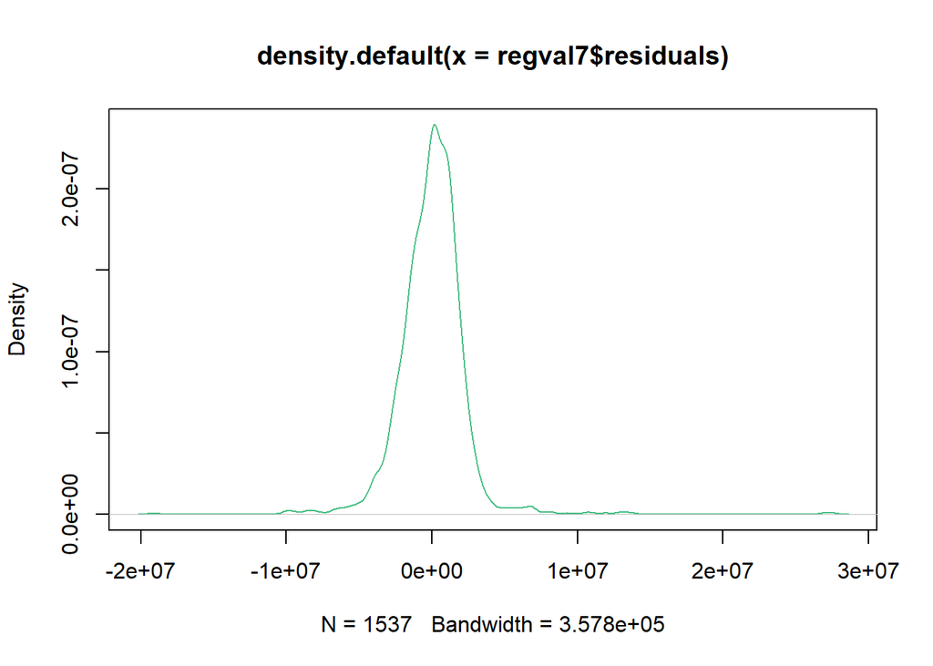

```r
plot(density(regval7$residuals), col=colorPalett[2])
```

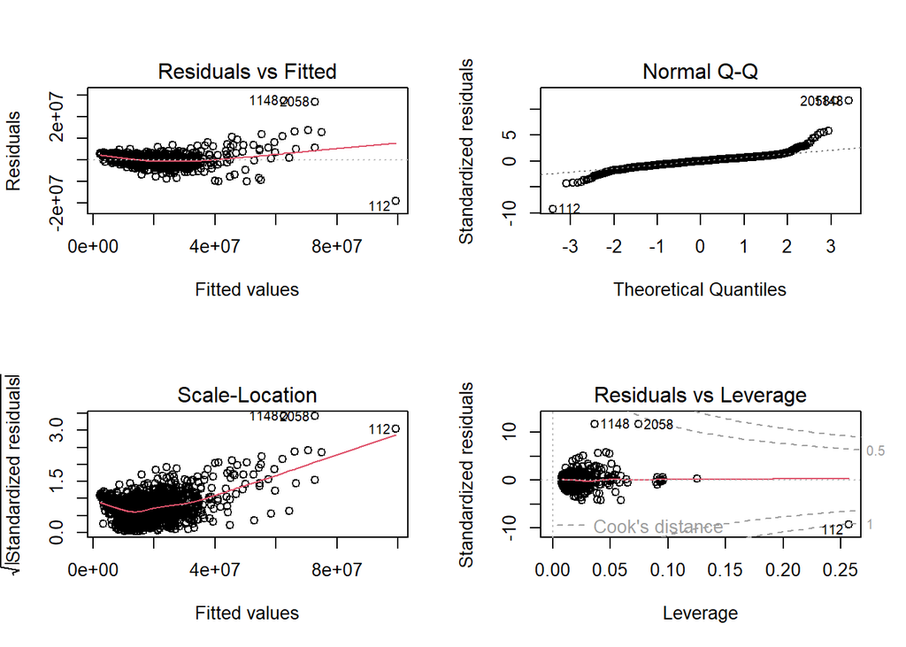

```r
par(mfrow = c(2,2))
plot(regval7)
```

```r
par(mfrow = c(1,1))
```

### *9. Obtenga el valor del R2 de predicción en la muestra test.*

```r
pred = predict(regval7, newdata = setTest)
head(pred)
```

```
##        5       10       11       16       21       22
## 22155849  8545350 19190157 11526307  6544958  6544958
```

```r
predSSE = sum((setTest$Valor-pred)^2)
R2test = 1 - predSSE/(var(setTest$Valor)*(792-1))
cat("R2test: ",R2test)
```

```
## R2test:  0.9414954
```

### *10. Obtenga el fichero con las predicciones del valor de las viviendas con su intervalo de confianza del 95%, para los pisos de la muestra test.*

```r
pred_int = predict(regval7, newdata = setTest, interval = "confidence")
head(pred_int,30)
```

```
##         fit      lwr      upr
## 5  22155849 21249489 23062210
## 10  8545350  7878385  9212316
## 11 19190157 18396269 19984046
## 16 11526307 10637656 12414959
## 21  6544958  5852750  7237166
## 22  6544958  5852750  7237166
## 24  4229199  3636127  4822270
## 25  6782383  6128892  7435874
## 28  9557612  8854199 10261025
## 30 30009778 29309626 30709930
## 34  4345656  3707902  4983410
## 36  3437499  2797608  4077390
## 43 30009778 29309626 30709930
## 44 10070783  9327871 10813696
```

[output cut: 16 more lines]